# Advanced Analytics Project

Prajwal Bharti

# Introduction

This project applies classification and regression techniques to two real-world datasets. - The first dataset focuses on detecting the presence of heart disease using classification models (Decision Tree and k-Nearest Neighbors). - The second predicts student academic performance using Multiple Linear Regression. - The goal is to build, evaluate, and compare models, and to interpret their performance and insights gained.

# Dataset 1: Heart Disease (Classification)

## Dataset Description

I have sourced this dataset from the UCI Cleveland Heart Disease dataset. It includes 13 predictors such as age, sex, chest pain type, blood pressure, cholesterol, and more. The target variable indicates the presence (`Yes`) or absence (`No`) of heart disease.

```r
heart <- read.csv("processed.cleveland.data", header = FALSE)
colnames(heart) <- c("age", "sex", "cp", "trestbps", "chol", "fbs", "restecg",
                     "thalach", "exang", "oldpeak", "slope", "ca", "thal", "target")

heart$target <- ifelse(heart$target == 0, "No", "Yes")
heart$target <- as.factor(heart$target)
```

## Exploratory Data Analysis

```r
library(ggplot2)
library(caret)
summary(heart)
```

```
##       age             sex               cp           trestbps
##  Min.   :29.00   Min.   :0.0000   Min.   :1.000   Min.   : 94.0
##  1st Qu.:48.00   1st Qu.:0.0000   1st Qu.:3.000   1st Qu.:120.0
##  Median :56.00   Median :1.0000   Median :3.000   Median :130.0
##  Mean   :54.44   Mean   :0.6799   Mean   :3.158   Mean   :131.7
##  3rd Qu.:61.00   3rd Qu.:1.0000   3rd Qu.:4.000   3rd Qu.:140.0
##  Max.   :77.00   Max.   :1.0000   Max.   :4.000   Max.   :200.0
##       chol            fbs            restecg          thalach
##  Min.   :126.0   Min.   :0.0000   Min.   :0.0000   Min.   : 71.0
##  1st Qu.:211.0   1st Qu.:0.0000   1st Qu.:0.0000   1st Qu.:133.5
##  Median :241.0   Median :0.0000   Median :1.0000   Median :153.0
##  Mean   :246.7   Mean   :0.1485   Mean   :0.9901   Mean   :149.6
##  3rd Qu.:275.0   3rd Qu.:0.0000   3rd Qu.:2.0000   3rd Qu.:166.0
##  Max.   :564.0   Max.   :1.0000   Max.   :2.0000   Max.   :202.0
##      exang           oldpeak         slope            ca
##  Min.   :0.0000   Min.   :0.00   Min.   :1.000   Length:303
##  1st Qu.:0.0000   1st Qu.:0.00   1st Qu.:1.000   Class :character
##  Median :0.0000   Median :0.80   Median :2.000   Mode  :character
##  Mean   :0.3267   Mean   :1.04   Mean   :1.601
##  3rd Qu.:1.0000   3rd Qu.:1.60   3rd Qu.:2.000
##  Max.   :1.0000   Max.   :6.20   Max.   :3.000
##      thal           target
##  Length:303         No :164
##  Class :character   Yes:139
##  Mode  :character
##
##
##
```

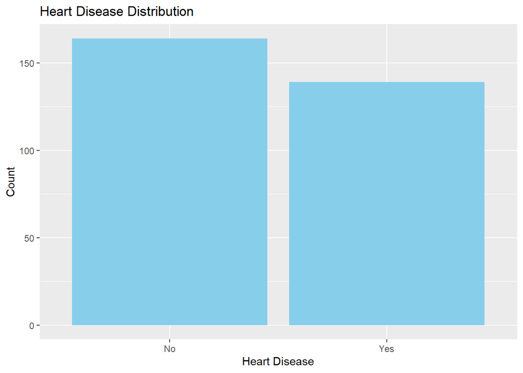

```r
ggplot(heart, aes(x = target)) +
  geom_bar(fill = "skyblue") +
  labs(title = "Heart Disease Distribution", x = "Heart Disease", y = "Count")
```

The target variable is moderately imbalanced, with slightly more individuals not having heart disease. This could affect the performance of the classifier models.

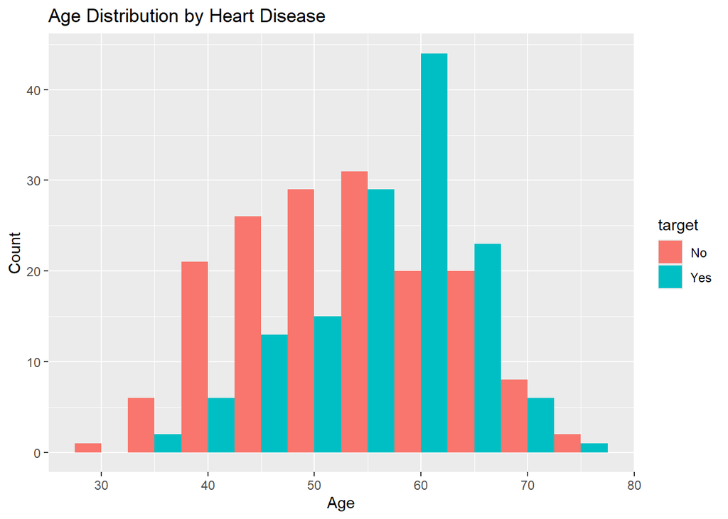

```r
#shows age distribution of heart disease patients
ggplot(heart, aes(x = age, fill = target)) +
  geom_histogram(binwidth = 5, position = "dodge") +
  labs(title = "Age Distribution by Heart Disease", x = "Age", y = "Count")
```

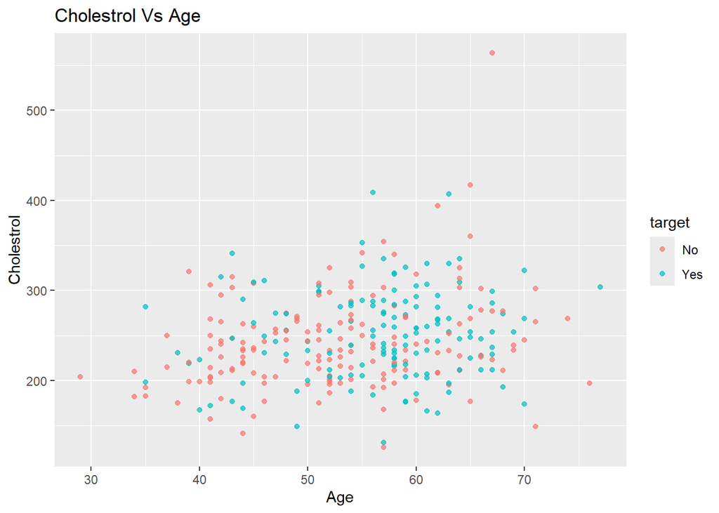

```r
#shows age distribution of heart disease patients
ggplot(heart, aes(x = age, y = chol, color = target)) +
  geom_point(alpha = 0.7) +
  labs(title = "Cholestrol Vs Age", x = "Age",y = "Cholestrol")
```

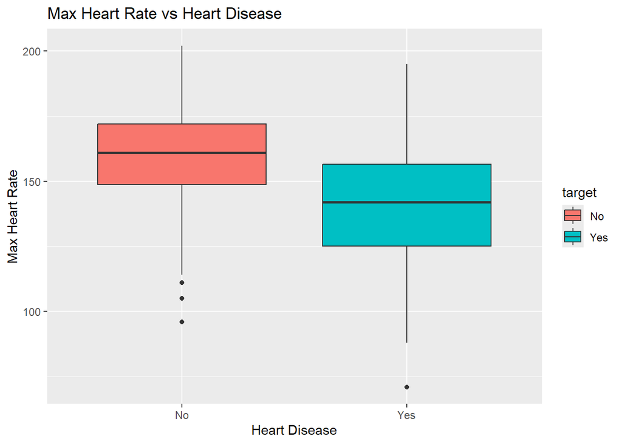

```r
#shows age distribution of heart disease patients
ggplot(heart, aes(x = target, y = thalach, fill = target)) +
  geom_boxplot() +
  labs(title = "Max Heart Rate vs Heart Disease", x = "Heart Disease", y = "Max Heart Rate")
```

This box plot compares maximum heart rate achieved during exercise stress tests between patients with and without heart disease. The patients with heart disease has low heart rate and viceversa for the patients with no heart disease

# Decision Tree Classification

## Train-Test Split

```r
set.seed(123)
split <- createDataPartition(heart$target, p = 0.8, list = FALSE)
train <- heart[split, ]
test <- heart[-split, ]
```

So here we have set the seed to 123 for higher reproducibility, so whenever we use this code again the split should take the same data everytime so the model do not change everytime Further, we split the data training data into 80% and testing data into 20%

## Model Training and Visualization

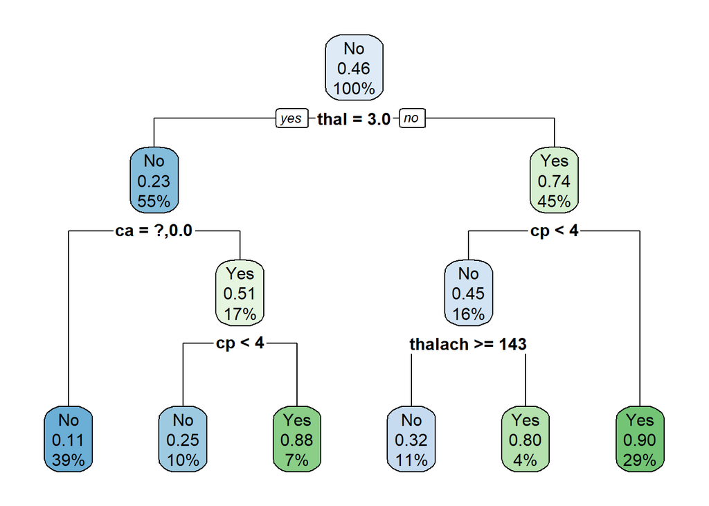

```r
library(rpart)
library(rpart.plot)

tree_model <- rpart(target ~ ., data = train, method = "class")
rpart.plot(tree_model)
```

## Evaluation

```r
tree_pred <- predict(tree_model, test, type = "class")
confusionMatrix(tree_pred, test$target)
```

```
## Confusion Matrix and Statistics
##
##           Reference
## Prediction No Yes
##        No  27   6
##        Yes  5  21
##
##                Accuracy : 0.8136
##                  95% CI : (0.6909, 0.9031)
##     No Information Rate : 0.5424
##     P-Value [Acc > NIR] : 1.224e-05
##
##                   Kappa : 0.6233
##
##  Mcnemar's Test P-Value : 1
##
##             Sensitivity : 0.8438
##             Specificity : 0.7778
##          Pos Pred Value : 0.8182
##          Neg Pred Value : 0.8077
##              Prevalence : 0.5424
##          Detection Rate : 0.4576
##    Detection Prevalence : 0.5593
##       Balanced Accuracy : 0.8108
##
##        'Positive' Class : No
##
```

The decision tree model achieved 81% accuracy with balanced sensitivity and specificity, indicating good generalization on unseen data.

# k-Nearest Neighbors Classification

## Data Normalization

```r
library(class)
normalize <- function(x) {(x - min(x)) / (max(x) - min(x))}
heart_features <- heart[, -which(names(heart) == "target")]
heart_numeric <- heart_features[, sapply(heart_features, is.numeric)]
heart_norm <- as.data.frame(lapply(heart_numeric, normalize))
heart_norm$target <- heart$target
```

So here we normalize data in between 0 and 1 excluding the target because we have to predict it for the test data. The normalization is done because KNN is sensitive to scale

## Train-Test Split

```r
set.seed(123)
split <- createDataPartition(heart_norm$target, p = 0.8, list = FALSE)
knn_train <- heart_norm[split, ]
knn_test <- heart_norm[-split, ]
```

Here we are spitting the data 80% Training data and rest for testing

## Model Tuning and Evaluation

```r
knn_pred3 <- knn(train = knn_train[, -ncol(knn_train)],
                 test = knn_test[, -ncol(knn_test)],
                 cl = knn_train$target,
                 k = 3)

knn_pred5 <- knn(train = knn_train[, -ncol(knn_train)],
                 test = knn_test[, -ncol(knn_test)],
                 cl = knn_train$target,
                 k = 5)

knn_pred7 <- knn(train = knn_train[, -ncol(knn_train)],
                 test = knn_test[, -ncol(knn_test)],
                 cl = knn_train$target,
                 k = 7)

# Comparing the knn prediction with actual target column
confusionMatrix(knn_pred3, knn_test$target)
```

```
## Confusion Matrix and Statistics
##
##           Reference
## Prediction No Yes
##        No  24   8
##        Yes  8  19
##
##                Accuracy : 0.7288
##                  95% CI : (0.5973, 0.8364)
##     No Information Rate : 0.5424
##     P-Value [Acc > NIR] : 0.002578
##
##                   Kappa : 0.4537
##
##  Mcnemar's Test P-Value : 1.000000
##
##             Sensitivity : 0.7500
##             Specificity : 0.7037
##          Pos Pred Value : 0.7500
##          Neg Pred Value : 0.7037
##              Prevalence : 0.5424
##          Detection Rate : 0.4068
##    Detection Prevalence : 0.5424
##       Balanced Accuracy : 0.7269
##
##        'Positive' Class : No
##
```

```r
confusionMatrix(knn_pred5, knn_test$target)
```

```
## Confusion Matrix and Statistics
##
##           Reference
## Prediction No Yes
##        No  24  11
##        Yes  8  16
##
##                Accuracy : 0.678
##                  95% CI : (0.5436, 0.7938)
##     No Information Rate : 0.5424
##     P-Value [Acc > NIR] : 0.02391
##
##                   Kappa : 0.3456
##
##  Mcnemar's Test P-Value : 0.64636
##
##             Sensitivity : 0.7500
##             Specificity : 0.5926
##          Pos Pred Value : 0.6857
##          Neg Pred Value : 0.6667
##              Prevalence : 0.5424
##          Detection Rate : 0.4068
##    Detection Prevalence : 0.5932
##       Balanced Accuracy : 0.6713
##
##        'Positive' Class : No
##
```

```r
confusionMatrix(knn_pred7, knn_test$target)
```

```
## Confusion Matrix and Statistics
##
##           Reference
## Prediction No Yes
##        No  24  10
##        Yes  8  17
##
##                Accuracy : 0.6949
##                  95% CI : (0.5613, 0.8081)
##     No Information Rate : 0.5424
##     P-Value [Acc > NIR] : 0.01224
##
##                   Kappa : 0.3818
##
##  Mcnemar's Test P-Value : 0.81366
##
##             Sensitivity : 0.7500
##             Specificity : 0.6296
##          Pos Pred Value : 0.7059
##          Neg Pred Value : 0.6800
##              Prevalence : 0.5424
##          Detection Rate : 0.4068
##    Detection Prevalence : 0.5763
##       Balanced Accuracy : 0.6898
##
##        'Positive' Class : No
##
```

# Dataset 2: Student Performance (Regression)

## Dataset Description

This dataset includes various demographic and academic factors for students in a math course. The target variable is the final grade (`G3`). Predictors include first and second period grades (`G1`, `G2`), study time, and more.

```r
library('dplyr')
student <- read.csv("student-mat.csv", sep = ";")
student <- student %>% mutate_if(is.character, as.factor)
summary(student)
```

```
##  school   sex          age       address famsize   Pstatus      Medu
##  GP:349   F:208   Min.   :15.0   R: 88   GT3:281   A: 41   Min.   :0.000
##  MS: 46   M:187   1st Qu.:16.0   U:307   LE3:114   T:354   1st Qu.:2.000
##                   Median :17.0                             Median :3.000
##                   Mean   :16.7                             Mean   :2.749
##                   3rd Qu.:18.0                             3rd Qu.:4.000
##                   Max.   :22.0                             Max.   :4.000
##       Fedu             Mjob           Fjob            reason      guardian
##  Min.   :0.000   at_home : 59   at_home : 20   course    :145   father: 90
##  1st Qu.:2.000   health  : 34   health  : 18   home      :109   mother:273
##  Median :2.000   other   :141   other   :217   other     : 36   other : 32
##  Mean   :2.522   services:103   services:111   reputation:105
##  3rd Qu.:3.000   teacher : 58   teacher : 29
##  Max.   :4.000
##    traveltime      studytime        failures      schoolsup famsup     paid
##  Min.   :1.000   Min.   :1.000   Min.   :0.0000   no :344   no :153   no :214
##  1st Qu.:1.000   1st Qu.:1.000   1st Qu.:0.0000   yes: 51   yes:242   yes:181
##  Median :1.000   Median :2.000   Median :0.0000
##  Mean   :1.448   Mean   :2.035   Mean   :0.3342
##  3rd Qu.:2.000   3rd Qu.:2.000   3rd Qu.:0.0000
##  Max.   :4.000   Max.   :4.000   Max.   :3.0000
##  activities nursery   higher    internet  romantic      famrel
##  no :194    no : 81   no : 20   no : 66   no :263   Min.   :1.000
##  yes:201    yes:314   yes:375   yes:329   yes:132   1st Qu.:4.000
##                                                     Median :4.000
##                                                     Mean   :3.944
##                                                     3rd Qu.:5.000
##                                                     Max.   :5.000
##     freetime         goout            Dalc            Walc
##  Min.   :1.000   Min.   :1.000   Min.   :1.000   Min.   :1.000
##  1st Qu.:3.000   1st Qu.:2.000   1st Qu.:1.000   1st Qu.:1.000
##  Median :3.000   Median :3.000   Median :1.000   Median :2.000
##  Mean   :3.235   Mean   :3.109   Mean   :1.481   Mean   :2.291
##  3rd Qu.:4.000   3rd Qu.:4.000   3rd Qu.:2.000   3rd Qu.:3.000
##  Max.   :5.000   Max.   :5.000   Max.   :5.000   Max.   :5.000
##      health         absences            G1              G2
##  Min.   :1.000   Min.   : 0.000   Min.   : 3.00   Min.   : 0.00
##  1st Qu.:3.000   1st Qu.: 0.000   1st Qu.: 8.00   1st Qu.: 9.00
##  Median :4.000   Median : 4.000   Median :11.00   Median :11.00
##  Mean   :3.554   Mean   : 5.709   Mean   :10.91   Mean   :10.71
##  3rd Qu.:5.000   3rd Qu.: 8.000   3rd Qu.:13.00   3rd Qu.:13.00
##  Max.   :5.000   Max.   :75.000   Max.   :19.00   Max.   :19.00
##        G3
##  Min.   : 0.00
##  1st Qu.: 8.00
##  Median :11.00
##  Mean   :10.42
##  3rd Qu.:14.00
##  Max.   :20.00
```

## Correlation Analysis

```r
cor_student <- cor(student[sapply(student, is.numeric)])
print(cor_student)
```

```
##                     age         Medu         Fedu   traveltime    studytime
## age         1.000000000 -0.163658419 -0.163438069  0.070640721 -0.004140037
## Medu       -0.163658419  1.000000000  0.623455112 -0.171639305  0.064944137
## Fedu       -0.163438069  0.623455112  1.000000000 -0.158194054 -0.009174639
## traveltime  0.070640721 -0.171639305 -0.158194054  1.000000000 -0.100909119
## studytime  -0.004140037  0.064944137 -0.009174639 -0.100909119  1.000000000
## failures    0.243665377 -0.236679963 -0.250408444  0.092238746 -0.173563031
## famrel      0.053940096 -0.003914458 -0.001369727 -0.016807986  0.039730704
## freetime    0.016434389  0.030890867 -0.012845528 -0.017024944 -0.143198407
## goout       0.126963880  0.064094438  0.043104668  0.028539674 -0.063903675
## Dalc        0.131124605  0.019834099  0.002386429  0.138325309 -0.196019263
## Walc        0.117276052 -0.047123460 -0.012631018  0.134115752 -0.253784731
## health     -0.062187369 -0.046877829  0.014741537  0.007500606 -0.075615863
## absences    0.175230079  0.100284818  0.024472887 -0.012943775 -0.062700175
## G1         -0.064081497  0.205340997  0.190269936 -0.093039992  0.160611915
## G2         -0.143474049  0.215527168  0.164893393 -0.153197963  0.135879999
## G3         -0.161579438  0.217147496  0.152456939 -0.117142053  0.097819690
##               failures       famrel    freetime        goout         Dalc
## age         0.24366538  0.053940096  0.01643439  0.126963880  0.131124605
## Medu       -0.23667996 -0.003914458  0.03089087  0.064094438  0.019834099
## Fedu       -0.25040844 -0.001369727 -0.01284553  0.043104668  0.002386429
## traveltime  0.09223875 -0.016807986 -0.01702494  0.028539674  0.138325309
## studytime  -0.17356303  0.039730704 -0.14319841 -0.063903675 -0.196019263
## failures    1.00000000 -0.044336626  0.09198747  0.124560922  0.136046931
## famrel     -0.04433663  1.000000000  0.15070144  0.064568411 -0.077594357
## freetime    0.09198747  0.150701444  1.00000000  0.285018715  0.209000848
## goout       0.12456092  0.064568411  0.28501871  1.000000000  0.266993848
## Dalc        0.13604693 -0.077594357  0.20900085  0.266993848  1.000000000
## Walc        0.14196203 -0.113397308  0.14782181  0.420385745  0.647544230
## health      0.06582728  0.094055728  0.07573336 -0.009577254  0.077179582
## absences    0.06372583 -0.044354095 -0.05807792  0.044302220  0.111908026
## G1         -0.35471761  0.022168316  0.01261293 -0.149103967 -0.094158792
## G2         -0.35589563 -0.018281347 -0.01377714 -0.162250034 -0.064120183
## G3         -0.36041494  0.051363429  0.01130724 -0.132791474 -0.054660041
##                   Walc       health    absences          G1          G2
## age         0.11727605 -0.062187369  0.17523008 -0.06408150 -0.14347405
## Medu       -0.04712346 -0.046877829  0.10028482  0.20534100  0.21552717
## Fedu       -0.01263102  0.014741537  0.02447289  0.19026994  0.16489339
## traveltime  0.13411575  0.007500606 -0.01294378 -0.09303999 -0.15319796
## studytime  -0.25378473 -0.075615863 -0.06270018  0.16061192  0.13588000
```

[output cut: 13 more lines]

```
## Medu        0.21714750
## Fedu        0.15245694
## traveltime -0.11714205
## studytime   0.09781969
## failures   -0.36041494
## famrel      0.05136343
## freetime    0.01130724
## goout      -0.13279147
## Dalc       -0.05466004
## Walc       -0.05193932
## health     -0.06133460
## absences    0.03424732
## G1          0.80146793
## G2          0.90486799
## G3          1.00000000
```

G1 and G2 show high correlation with G3, as expected. These are key predictors for the regression model.

# Multiple Linear Regression

## Full Model

```r
student.lm <- lm(G3 ~ G1 + G2 + studytime, data = student)
summary(student.lm)
```

```
##
## Call:
## lm(formula = G3 ~ G1 + G2 + studytime, data = student)
##
## Residuals:
##     Min      1Q  Median      3Q     Max
## -9.5711 -0.3434  0.2819  0.9729  3.5542
##
## Coefficients:
##             Estimate Std. Error t value Pr(>|t|)
## (Intercept) -1.56129    0.38371  -4.069 5.72e-05 ***
## G1           0.16025    0.05631   2.846  0.00466 **
## G2           0.98673    0.04950  19.933  < 2e-16 ***
## studytime   -0.16873    0.11765  -1.434  0.15230
## ---
## Signif. codes:  0 '***' 0.001 '**' 0.01 '*' 0.05 '.' 0.1 ' ' 1
##
## Residual standard error: 1.934 on 391 degrees of freedom
## Multiple R-squared:  0.8231, Adjusted R-squared:  0.8217
## F-statistic: 606.4 on 3 and 391 DF,  p-value: < 2.2e-16
```

## Predictions

```r
new_student <- data.frame(G1 = 13, G2 = 16, studytime = 3)
predict(student.lm, new_student)
```

```
##        1
## 15.80349
```

```r
predict(student.lm, new_student, interval = "confidence")
```

```
##        fit      lwr      upr
## 1 15.80349 15.36314 16.24384
```

```r
predict(student.lm, new_student, interval = "predict")
```

```
##        fit      lwr      upr
## 1 15.80349 11.97506 19.63191
```

## Exploratory Data Analysis

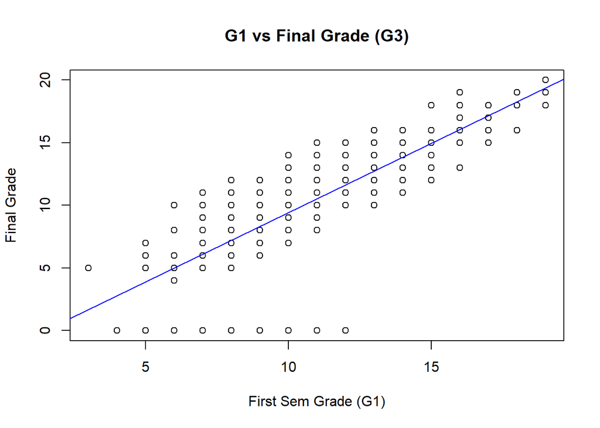

```r
# G1(Grade 1) vs G3(Grade 1)
plot(G3 ~ G1, data = student, main = "G1 vs Final Grade (G3)",
     xlab = "First Sem Grade (G1)", ylab = "Final Grade")
abline(lm(G3 ~ G1, data = student), col = "blue")
```

This graph illustrates a strong trend that indicates that student who has good G1(Grade1) he also has good final grades. This confirms strong relation G1(Grade1) and Final Grade

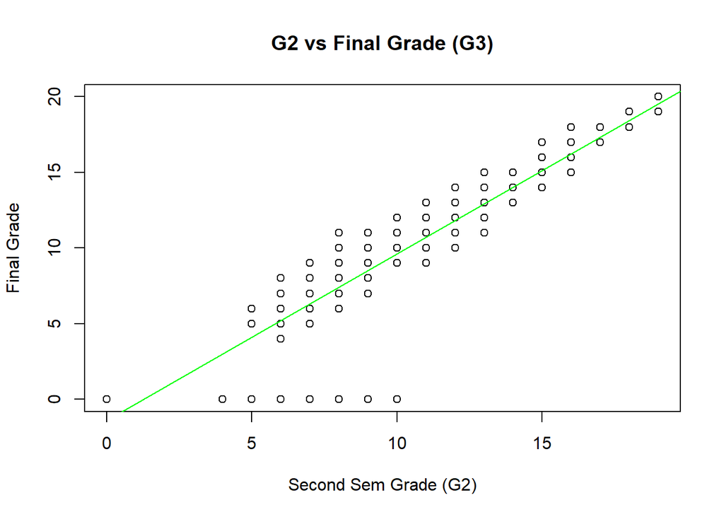

```r
# G2(Grade 1) vs G3(Grade 1)
plot(G3 ~ G2, data = student, main = "G2 vs Final Grade (G3)",
     xlab = "Second Sem Grade (G2)", ylab = "Final Grade")
abline(lm(G3 ~ G2, data = student), col = "green")
```

The scatter plot illustrates the relationship between students’ second-period grades (G2) and their final grades (G3). A strong positive correlation is evident, indicating that students who perform well in the second period tend to maintain high performance through to the final period.

## Model Evaluation

```r
predicted_g3 <- predict(student.lm)
actual_g3 <- student$G3
rmse <- sqrt(mean((predicted_g3 - actual_g3)^2))
cat("RMSE:", rmse)
```

```
## RMSE: 1.924523
```

The Root Mean Squared Error (RMSE) indicates a good level of accuracy in grade prediction.

## Reduced Model Comparison

```r
student.lm2 <- lm(G3 ~ G1 + studytime, data = student)
summary(student.lm2)
```

```
##
## Call:
## lm(formula = G3 ~ G1 + studytime, data = student)
##
## Residuals:
##      Min       1Q   Median       3Q      Max
## -11.4629  -0.8060   0.3639   1.7038   5.0437
##
## Coefficients:
##             Estimate Std. Error t value Pr(>|t|)
## (Intercept) -1.37702    0.54398  -2.531   0.0118 *
## G1           1.11329    0.04218  26.392   <2e-16 ***
## studytime   -0.17318    0.16683  -1.038   0.2999
## ---
## Signif. codes:  0 '***' 0.001 '**' 0.01 '*' 0.05 '.' 0.1 ' ' 1
##
## Residual standard error: 2.743 on 392 degrees of freedom
## Multiple R-squared:  0.6433, Adjusted R-squared:  0.6415
## F-statistic: 353.5 on 2 and 392 DF,  p-value: < 2.2e-16
```

```r
summary(student.lm)$r.squared
```

```
## [1] 0.8230939
```

```r
summary(student.lm2)$r.squared
```

```
## [1] 0.6433313
```

Excluding G2 reduced the R-squared, confirming G2 is an important predictor.

# Reflection

In this project I have applied both classification and regression modeling using R. I have gained experience in working with real-world datasets, cleaning and transforming the data, visualizing data and interpreting model outputs

One of the most valuable aspects of this project was understanding the need for proper preprocessing. By using kNN, I learned how essential normalization is when dealing with distance-based algorithms. At first, I encountered errors trying to normalize all columns, but then realized I had to apply normalization only to numeric features, excluding factors and characters. This helped me develop a better understanding of how data types affect model readiness.

In the regression section, I built a multiple linear regression model to predict final grades G3(Grade3) based on G1(Grade1), G2(Grade2), and study time. G1(Grade1) and G2(Grade2) were the strong predictors with significant p-values, and the model achieved an adjusted R-squared of ~0.82 and low RMSE. This made me understand of how past performance strongly impacts future academic outcomes. In last I also compared a reduced model by excluding the G2(Grade2) and noticed a drop in R-squared, confirming its importance.

One technical challenge I faced was selecting which predictors to keep. Including too many variables could lead to overfitting, but excluding important ones could weaken the model. Balancing this taught me the importance of model simplification and evaluation through metrics like RMSE and adjusted R-squared.

Overall, this project deepened my understanding of how Decision tree, KNN and Regression works. How the data modeling is done. how to deal with the real world data. It also improved my coding fluency in R, especially with libraries like `caret`, `class`, and `rpart`. More importantly, it taught me how to how to analyse the outcome i.e how to summarize it and come to the conclusion that which one is better. I now feel more confident approaching similar analytics tasks in future projects or real-world scenarios.